# presentacion_clase_46 slides

[figure not shown]

DATA SCIENCE

MÓDULO 6

Text Minig  
Preprocesamiento de texto

## Agenda

- Introducción
- Bag of words
- Corpus y documentos
- Tokenización
- Construcción de un vocabulario
- Stemming y Lemmatization
- Encoding
- Singular Value Decomposition

Introducción

[figure not shown]

## ¿Qué es Text Mining?

Text Mining es el conjunto de **técnicas que se utilizan para explorar grandes cantidades de texto**, de manera automática o semiautomática, para descubrir patrones repetitivos, tendencias o reglas que explican el comportamiento del texto.

El objetivo es ayudar a **comprender el contenido de un conjunto de textos** por medio de estadísticas y algoritmos de búsqueda.

En esta clase **analizaremos datos de tipo texto**. Algo hemos hecho ya cuando preprocesamos datasets usando, por ejemplo, expresiones regulares. Lo que hacíamos en ese entonces era buscar algo que ya sabíamos que estaba allí. La tarea que nos ocupa ahora es diferente. Queremos usar los **algoritmos de machine learning que aprendimos para hacer clasificación, pero ahora con textos**.

Existen múltiples escenarios en los cuales querríamos hacer esto. Uno de los primeros problemas de aplicación de machine learning, de hecho, fue el de clasificación de correos como spam o no-spam. Otros casos son la clasificación de comentarios de usuarios sobre algún producto como positivos o negativos, identificar a qué sección de un diario pertenecen distintas notas, etc.

En resumen, **queremos extraer información sobre el contenido de los textos**.

## Técnicas de text mining y su funcionalidad

[figure not shown]

Fuente: [Text Mining: Techniques, Applications and Issues](https://www.researchgate.net/publication/311394659_Text_Mining_Techniques_Applications_and_Issues)

- Clasificación de documentos: clasificación de texto, estandarización de elementos
- Recuperación de información: búsqueda de palabras clave/ consulta e indexación
- Agrupación de documentos: agrupación de frases
- Procesamiento del lenguaje natural: corrección ortográfica, lematización, análisis gramatical y desambiguación del sentido de las palabras
- Extracción de información: extracción de relaciones / análisis de enlaces
- Web mining

## Features

Para poder implementar los modelos que ya conocemos, **necesitamos representar los datos como una matriz de features**.

En el caso de modelos de aprendizaje supervisado, necesitamos además una etiqueta.

**¿Cómo convertirían un texto en una matriz de features?**

La propuesta más simple es contar la ocurrencia de los términos que aparecen en los textos.

Vamos a representar un texto como una **matriz donde cada fila es un documento y cada columna una palabra**.

## El problema de la dimensionalidad

Los textos son secuencias de palabras (y signos de puntuación!) y el sentido de los mismos está contenido precisamente en las estructuras semánticas que forman estos elementos combinados.

**El sentido no está dado por la mera presencia de las palabras, sino por cómo se articulan**.

Queremos buscar una estructura en el *espacio de los textos posibles*.

El problema es que ese **espacio es de una dimensionalidad enorme**.

Para poder computar métricas de distancia entre los textos, para poder entrenar algoritmos de machine learning que nos permitan encontrar patrones en los datos, necesitamos **definir representaciones reducidas de los textos**.

Bag of words

[figure not shown]

## Bag of words

Una de las maneras más simples y efectivas de representar los textos es la que se conoce como **"bag of words"**

Consiste en descartar la mayor parte de la estructura de los textos como párrafos, capítulos, etc, y conservar únicamente el conjunto de palabras y el número de veces que aparecen en el texto.

Es decir, olvidamos el orden en que aparecen. Matemáticamente, el número de maneras en que podemos ordenar n elementos se calcula como n! (se lee 'factorial de n' o 'n factorial') y vale:

$n!=n*(n-1)*(n-2)*(n-3)*...*3*2*1$

Es decir que si tuviéramos 10 palabras diferentes para construir un texto (una oración), podríamos construir $3628800$ textos distintos ya que

$10!=10*9*8*7*6*5*4*3*2*1 = 3628800 $

Pero en el esquema "bag of words" todos ellos estarían representados de la misma manera (la misma bolsa de palabras), de manera que serían textos indistinguibles.

Corpus y documentos

[figure not shown]

## Corpus y documentos

Llamaremos **corpus** a un conjunto de textos y **documento** a cada texto que compone el corpus (puede ser un libro, un twit o el comentario de un usuario) y que a la vez es nuestra unidad de dato (sería una fila en un dataframe).

Computar la representación "bag of words" de un corpus de documentos conlleva tres pasos:

1. **Tokenización**: convertir cada documento a una lista de palabras (y signos de puntuación) que lo componen.
2. **Construcción de un vocabulario**: colectar todas las palabras que se registraron en el corpus y ordenarlas (típicamente por orden alfabético).
3. **Encoding**: representar los documentos como vectores en el espacio de las palabras del vocabulario.

Veremos cada uno de estos pasos en detalle y luego incorporaremos herramientas de sklearn que permiten aglutinar todo en un sólo modelo.

## Preprocesamiento

[NLTK (Natural Language Toolkit)](https://www.nltk.org) es una librería de python de código abierto para el procesamiento de lenguaje natural.

Tiene un libro online gratuito para consultar:

Steven Bird, Ewan Klein, and Edward Loper (2009). Natural Language Processing with Python. O’Reilly Media Inc. http://nltk.org/book

Tokenización

[figure not shown]

### Tokenización

Los **tokens son típicamente las palabras y signos de puntuación**.

Tokenización es la **transformación de un texto a unidades constitutivas llamadas tokens**.

La librería NLTK cuenta con herramientas para hacer ésto, identificando los signos de puntuación: cuándo los mismos separan oraciones y cuándo cumplen otra función, como una abreviatura.

```python
import nltk
nltk.download('punkt')    # esta linea deben ejecutarla sólo una vez
nltk.download('stopwords') # esta linea deben ejecutarla sólo una vez
nltk.download('wordnet')    # esta linea deben ejecutarla sólo una vez
from nltk.tokenize import word_tokenize, sent_tokenize
```

```python
sentence="Pythoners are very intelligent and work very pythonly and now they are pythoning their way to success."

print(word_tokenize(sentence))
```

```
['Pythoners', 'are', 'very', 'intelligent', 'and', 'work', 'very', 'pythonly', 'and', 'now', 'they', 'are', 'pythoning', 'their', 'way', 'to', 'success', '.']
```

Por otro lado, si quisiéramos obtener una lista de oraciones

```python
text = "This is the first sentence. A gallon of milk in the U.S. costs $2.99. \
    Is this the third sentence? Yes, it is!"

print('Tokenizamos usando sent_tokenize:')
print(sent_tokenize(text))
```

```
Tokenizamos usando sent_tokenize:
['This is the first sentence.', 'A gallon of milk in the U.S. costs $2.99.', 'Is this the third sentence?', 'Yes, it is!']
```

Es posible que en algunos casos el tokenizador falle, por ejemplo no reconociendo una abreviatura.

En el siguiente ejemplo el tokenizador no reconoce 'al.' de modo que interpreta el punto como el fin de una oración.

```python
text2 = "According to Hotho et al. (2005) we can differ three different perspectives of text mining, \
namely text mining as information extraction, text mining as text data mining, and text mining as KDD \
(Knowledge Discovery in Databases) process. Text mining is 'the discovery by computer of new, \
previously unknown information, by automatically extracting information from different written resources."

print(sent_tokenize(text2))
```

```
['According to Hotho et al.', '(2005) we can differ three different perspectives of text mining, namely text mining as information extraction, text mining as text data mining, and text mining as KDD (Knowledge Discovery in Databases) process.', "Text mining is 'the discovery by computer of new, prev…
```

Podemos resolver este problema incluyendo abreviaturas al tokenizador.

Para ello, en lugar de importar el método sent_tokenize, instanciamos los objetos `PunkTrainer` y `PunktSentenceTokenizer`.

(La idea de la siguiente celda sólo es mostrar un ejemplo. Pueden consultar la documentación [aquí](http://www.nltk.org/api/nltk.tokenize.html?highlight=tokenizer#nltk.tokenize.punkt.PunktTrainer))

```python
from nltk.tokenize.punkt import PunktSentenceTokenizer, PunktTrainer

trainer = PunktTrainer()

trainer.INCLUDE_ALL_COLLOCS = True

tokenizer = PunktSentenceTokenizer(trainer.get_params())

tokenizer._params.abbrev_types.add('al')

print(tokenizer.tokenize(text2))
```

```
['According to Hotho et al. (2005) we can differ three different perspectives of text mining, namely text mining as information extraction, text mining as text data mining, and text mining as KDD (Knowledge Discovery in Databases) process.', "Text mining is 'the discovery by computer of new, previou…
```

Construcción de un vocabulario

[figure not shown]

### Construcción de un vocabulario

Vamos a **representar los textos como una bolsa de palabras**.

Podríamos tokenizar todos los documentos y definir el vocabulario como el set de palabras que aparecieron al menos una vez en todo el corpus.

Esto tiene el problema de que el número de palabras será muy grande y muchas de ellas serán muy poco informativas sobre el contenido del texto, por ejemplo las preposiciones, pronombres, etc.

A estas palabras se las llama **stopwords** y a menudo se las **excluye del vocabulario**.

Otra técnica para reducir la dimensionalidad del problema consiste en **agrupar palabras que comparten la misma raíz etimológica** como "correr", "corriendo", "corredor".

#### Stopwords

NLTK tiene listas de stopwords en distintos idiomas, podemos acceder a las mismas del siguiente modo:

```python
from nltk.corpus import stopwords

stopwords_sp = stopwords.words('spanish');

print('\n Las primeras 20 en español:')
print(stopwords_sp[:20])

stopwords_en = stopwords.words('english');

print('\n Las primeras 20 en ingles:')
print(stopwords_en[:20])
```

```
 Las primeras 20 en español:
['de', 'la', 'que', 'el', 'en', 'y', 'a', 'los', 'del', 'se', 'las', 'por', 'un', 'para', 'con', 'no', 'una', 'su', 'al', 'lo']

 Las primeras 20 en ingles:
['i', 'me', 'my', 'myself', 'we', 'our', 'ours', 'ourselves', 'you', "you're", "you've", "you'll", "you'd", 'your', 'yours', 'yourself', 'yourselves', 'he', 'him', 'his']
```

#### Stemming y Lemmatization

Stemming y lemmatization son **maneras de reducir las palabras a su raíz etimológica**.

**Stemming lo hace por sustracción de sufijos y prefijos de las palabras**.

La raíz que queda **(stem) muchas veces no es una palabra en sí misma**.

Por ejemplo al pasar la palabra "corriendo" por un stemmer obtenemos "corr".

[figure not shown]

Por el contrario, **el lematizador siempre devuelve una versión reducida de la palabra (lema), pero que es en sí misma una palabra de la misma familia**.

[figure not shown]

Para profundizar: [Stemming and Lemmatization in Python](https://www.datacamp.com/community/tutorials/stemming-lemmatization-python)

##### Stemming

```python
# Importamos los algoritmos de Stemming

from nltk.stem import PorterStemmer
from nltk.stem import LancasterStemmer

# Creamos objects a partir de las clases PorterStemmer y LancasterStemmer

porter = PorterStemmer()
lancaster=LancasterStemmer()
```

```python
# Le pasamos palabras a ambos algoritmos para que hagan stemming:
print("Porter Stemmer")
print(porter.stem("cats"))
print(porter.stem("trouble"))
print(porter.stem("troubling"))
print(porter.stem("troubled"))
print("\n")
print("Lancaster Stemmer")
print(lancaster.stem("cats"))
print(lancaster.stem("trouble"))
print(lancaster.stem("troubling"))
print(lancaster.stem("troubled"))
print("\n")
```

```
Porter Stemmer
cat
troubl
troubl
troubl


Lancaster Stemmer
cat
troubl
troubl
troubl
```

```python
# Creamos una lista de palabras para hacer stemming con ambos algoritmos:
word_list = ["friend", "friendship", "friends", "friendships", \
             "stabil","destabilize","misunderstanding",\
             "railroad","moonlight","football"]
print("{0:20}{1:20}{2:20}".format("Word","Porter Stemmer","lancaster Stemmer"))
for word in word_list:
    print("{0:20}{1:20}{2:20}".format(word,porter.stem(word),lancaster.stem(word)))
```

```
Word                Porter Stemmer      lancaster Stemmer
friend              friend              friend
friendship          friendship          friend
friends             friend              friend
friendships         friendship          friend
stabil              stabil              stabl
destabilize         destabil            dest
misunderstanding    misunderstand       misunderstand
railroad            railroad            railroad
moonlight           moonlight           moonlight
football            footbal             footbal
```

#### Stemmers en otros idiomas:

Python **nltk** no solo proporciona dos stemmers en inglés: PorterStemmer y LancasterStemmer, sino también muchos stemmers que no están en inglés como **SnowballStemmers**.

Idiomas que maneja **SnowballStemmers**:

- danés
- holandés
- inglés
- francés
- alemán
- húngaro
- italiano
- noruego
- portugués
- rumano
- ruso
- español
- sueco

```python
from nltk.stem.snowball import SnowballStemmer
word = 'having';
englishStemmer=SnowballStemmer("english")
print("{0:15}{1:10}".format(word, englishStemmer.stem(word)))

palabra = 'corriendo';
spanishStemmer=SnowballStemmer("spanish")
print("{0:15}{1:10}".format(palabra, spanishStemmer.stem(palabra)))
```

```
having         have
corriendo      corr
```

##### Lemmatization

```python
from nltk.stem import WordNetLemmatizer

wordnet_lemmatizer = WordNetLemmatizer()

sentence = "He was running and eating at same time. He has \
bad habit of swimming after playing long hours in the Sun."

sentence_words = word_tokenize(sentence);
```

```python
print("\n{0:20}{1:20}{2:20}\n".format("Word","Lemma",'Stem'))

for word in sentence_words:
    print ("{0:20}{1:20}{2:20}".format(word, wordnet_lemmatizer.lemmatize(word), englishStemmer.stem(word)))
```

```
Word                Lemma               Stem

He                  He                  he
was                 wa                  was
running             running             run
and                 and                 and
eating              eating              eat
at                  at                  at
same                same                same
time                time                time
.                   .                   .
He                  He                  he
has                 ha                  has
bad                 bad                 bad
habit               habit               habit
of                  of                  of
swimming            swimming            swim
after               after               after
playing             playing             play
long                long                long
hours               hour                hour
in                  in                  in
the                 the                 the
Sun                 Sun                 sun
.                   .                   .
```

Encoding

[figure not shown]

## Encoding

Podemos representar a los documentos en función de las palabras que los componen, sin considerar las estructuras semánticas que éstas forman.

De esta manera, **un documento puede representarse como un vector en el espacio de palabras que conforman el vocabulario**.

Existen diferentes maneras de definir estos vectores. La más intuitiva es contar el número de veces que aparece cada palabra en un documento y asignarlo como la coordenada o el peso correspondiente a dicha palabra en el vector.

[CountVectorizer](https://scikit-learn.org/stable/modules/generated/sklearn.feature_extraction.text.CountVectorizer.html) provee esta funcionalidad.

### `CountVectorizer`

Al momento de instanciarla, permite pasarle una lista de stopwords para que no las tenga en cuenta.

Como todos los modelos de sklearn, tiene los métodos fit y transform.

`fit` genera el vocabulario a partir de los documentos, y `transform` vectoriza los documentos al espacio del vocabulario.

Como típicamente el vocabulario es muy grande, las matrices son muy esparsas (tienen muchos ceros) por lo que es conveniente almacenar sólamente las entradas no nulas de las mismas en un objeto de la clase "sparse matrix". `CountVectorizer` genera matrices de esta clase.

```python
# Generamos textos

t0 = "El potro y el angel llegaron al cine por casualidad."
t1 = "El ángel, el tanque del cine nacional, un paso más cerca del oscar"
t2 = "final del mes del cine nacional: 'El Potro', la única cinta 'millonaria'"
t3 = "Juan Martin del potro volvió a tandil: se dio el ultimo baño de masas con los suyos."
t4 = "Juan Martin del potro fue recibido por una multitud en Tandil."
t5=  "Juan Martin del potro fue a ver 'El Potro' al cine y le encantó."
textos=[t0,t1,t2,t3,t4,t5];
```

```python
from sklearn.feature_extraction.text import CountVectorizer
from nltk.stem.snowball import SnowballStemmer

stopwords_sp = stopwords.words('spanish');

# si no hacemos esto y usamos directo stopwords_sp, CountVectorizer devuelve un warning
stopwords_sp_stem = [spanishStemmer.stem(x) for x in stopwords_sp]

vectorizer = CountVectorizer(stop_words = stopwords_sp_stem, lowercase = True, strip_accents = 'unicode');

vectorizer.fit(textos);
print('Vocabulario:\n',vectorizer.vocabulary_) # vocabulario del corpus con la frecuencia de cada término
```

```
Vocabulario:
 {'potro': 19, 'angel': 0, 'llegaron': 10, 'cine': 4, 'casualidad': 2, 'tanque': 23, 'nacional': 16, 'paso': 18, 'cerca': 3, 'oscar': 17, 'final': 8, 'mes': 13, 'unica': 25, 'cinta': 5, 'millonaria': 14, 'juan': 9, 'martin': 11, 'volvio': 27, 'tandil': 22, 'dio': 6, 'ultimo': 24, 'bano': 1, 'masas':…
```

```python
countvectorizer_encoding = vectorizer.transform(textos);
print('\n Transformamos los textos a una matriz esparsa:',type(countvectorizer_encoding))

pd.DataFrame(countvectorizer_encoding.todense(),
             columns = vectorizer.get_feature_names()) # Usamos el método .todense() para ver la matriz completa
```

```
 Transformamos los textos a una matriz esparsa: <class 'scipy.sparse.csr.csr_matrix'>
```

|  | angel | bano | casualidad | cerca | cine | cinta | dio | encanto | final | juan | ... | paso | potro | recibido | suyos | tandil | tanque | ultimo | unica | ver | volvio |
| --- | --- | --- | --- | --- | --- | --- | --- | --- | --- | --- | --- | --- | --- | --- | --- | --- | --- | --- | --- | --- | --- |
| 0 | 1 | 0 | 1 | 0 | 1 | 0 | 0 | 0 | 0 | 0 | ... | 0 | 1 | 0 | 0 | 0 | 0 | 0 | 0 | 0 | 0 |
| 1 | 1 | 0 | 0 | 1 | 1 | 0 | 0 | 0 | 0 | 0 | ... | 1 | 0 | 0 | 0 | 0 | 1 | 0 | 0 | 0 | 0 |
| 2 | 0 | 0 | 0 | 0 | 1 | 1 | 0 | 0 | 1 | 0 | ... | 0 | 1 | 0 | 0 | 0 | 0 | 0 | 1 | 0 | 0 |
| 3 | 0 | 1 | 0 | 0 | 0 | 0 | 1 | 0 | 0 | 1 | ... | 0 | 1 | 0 | 1 | 1 | 0 | 1 | 0 | 0 | 1 |
| 4 | 0 | 0 | 0 | 0 | 0 | 0 | 0 | 0 | 0 | 1 | ... | 0 | 1 | 1 | 0 | 1 | 0 | 0 | 0 | 0 | 0 |
| 5 | 0 | 0 | 0 | 0 | 1 | 0 | 0 | 1 | 0 | 1 | ... | 0 | 2 | 0 | 0 | 0 | 0 | 0 | 0 | 1 | 0 |

6 rows × 28 columns

### Term Frequency Inverse Document Frequency (TF-IDF)

La representación de los textos generada mediante `CountVectorizer` tiene en cuenta cuántas veces se observó cada término del vocabulario en cada documento.

**Problemas**:

- En un documento mucho más largo que los otros, el conteo de palabras puede resultar en números mucho mayores que en el resto de los documentos.

  Para corregir esta anomalía, deberíamos normalizar (dividir) el conteo de cada palabra por el tamaño de cada documento.
- Hay palabras que aparecen en muchos documentos y resultan entonces poco informativas para distinguirlos.

  Una palabra que aparece muchas veces en un documento, pero pocas veces en los demás, es una palabra muy distintiva de ese documento y será importante para representarlo, mientras que palabras que aparecen pocas veces, o que aparecen en muchos documentos serán menos informativas.

La transformación TF-IDF tiene en cuenta estos factores de la siguiente manera:

- El término 't' dentro del documento 'd' tiene un coeficiente tf-idf(t,d) que es el producto de dos factores:

\begin{equation} \text{tf-idf}(t,d)=\text{tf}(t,d) \times idf(t) \end{equation}

- tf(t,d) es la frecuencia de aparición de t dentro de d (normalizada).
- idf(t) es la *inverse document frecuency* del término t y se calcula como: \begin{equation} \text{idf}(t)=\log{\frac{N}{\text{df(t)+1}}} \end{equation}

en donde

- N es el número de documentos
- df(t) es el número de documentos en los que aparece el término t.
- Se suele sumar 1 en el denominador para no tener problemas si existe un término en el vocabulario que no aparece en ningún documento (df=0).

#### Ejemplo

document1 = 'el potro y el angel llegaron al cine por casualidad'

document2 = 'el angel el tanque del cine nacional un paso mas cerca del oscar'

document4 = 'juan martin del potro volvio a tandil se dio el ultimo bano de masas con los suyos'

Y los coeficientes tf-idf:

El coeficiente tf-idf para "potro" en el documento 1 da:

\begin{equation} \text{tf-idf('potro',doc1)}= \frac{1}{10} \times \log{\frac{4}{2}}=0.07\\ \end{equation}

#### TfidfVectorizer, TfidfTransformer

[figure not shown]

En sklearn, los objetos de la clase TfidfTransformer sirven para transformar una matriz generada por CountVectorizer().

Podemos saltearnos el uso de countvectorizer y usar directamente TfidfVectorizer.

A diferencia de la estimación clásica del factor idf que vimos más arriba, TfidfVectorizer y TfidfTransformer por defecto calculan una versión suavizada del idf como

\begin{equation} \text{idf(t)}= \log{\frac{N+1}{df(t)+1}}+1 \end{equation}

y luego normaliza los documentos vectorizados por su norma L2. (ver https://scikit-learn.org/stable/modules/feature_extraction.html#text-feature-extraction)

```python
from sklearn.feature_extraction.text import TfidfTransformer

Tfidf_encoding=TfidfTransformer().fit_transform(countvectorizer_encoding);

pd.DataFrame(Tfidf_encoding.todense(),columns=vectorizer.get_feature_names())
```

|  | angel | bano | casualidad | cerca | cine | cinta | dio | encanto | final | juan | ... | paso | potro | recibido | suyos | tandil | tanque | ultimo | unica | ver | volvio |
| --- | --- | --- | --- | --- | --- | --- | --- | --- | --- | --- | --- | --- | --- | --- | --- | --- | --- | --- | --- | --- | --- |
| 0 | 0.452305 | 0.000000 | 0.551581 | 0.000000 | 0.327231 | 0.000000 | 0.000000 | 0.000000 | 0.000000 | 0.000000 | ... | 0.000000 | 0.282590 | 0.000000 | 0.000000 | 0.000000 | 0.000000 | 0.000000 | 0.000000 | 0.000000 | 0.000000 |
| 1 | 0.343563 | 0.000000 | 0.000000 | 0.418971 | 0.248559 | 0.000000 | 0.000000 | 0.000000 | 0.000000 | 0.000000 | ... | 0.418971 | 0.000000 | 0.000000 | 0.000000 | 0.000000 | 0.418971 | 0.000000 | 0.000000 | 0.000000 | 0.000000 |
| 2 | 0.000000 | 0.000000 | 0.000000 | 0.000000 | 0.236607 | 0.398826 | 0.000000 | 0.000000 | 0.398826 | 0.000000 | ... | 0.000000 | 0.204329 | 0.000000 | 0.000000 | 0.000000 | 0.000000 | 0.000000 | 0.398826 | 0.000000 | 0.000000 |
| 3 | 0.000000 | 0.355931 | 0.000000 | 0.000000 | 0.000000 | 0.000000 | 0.355931 | 0.000000 | 0.000000 | 0.246415 | ... | 0.000000 | 0.182353 | 0.000000 | 0.355931 | 0.291868 | 0.000000 | 0.355931 | 0.000000 | 0.000000 | 0.355931 |
| 4 | 0.000000 | 0.000000 | 0.000000 | 0.000000 | 0.000000 | 0.000000 | 0.000000 | 0.000000 | 0.000000 | 0.350859 | ... | 0.000000 | 0.259643 | 0.506793 | 0.000000 | 0.415577 | 0.000000 | 0.000000 | 0.000000 | 0.000000 | 0.000000 |
| 5 | 0.000000 | 0.000000 | 0.000000 | 0.000000 | 0.284104 | 0.000000 | 0.000000 | 0.478888 | 0.000000 | 0.331540 | ... | 0.000000 | 0.490694 | 0.000000 | 0.000000 | 0.000000 | 0.000000 | 0.000000 | 0.000000 | 0.478888 | 0.000000 |

6 rows × 28 columns

Singular Value Decomposition (SVD)

[figure not shown]

## Singular Value Decomposition (SVD)

SVD es una técnica (general) de factorización de matrices.

Comprender la matemática involucrada excede las ambiciones de esta presentación. Para indagar en ella pueden consultar alguna de estas referencias:

*Practical Text Mining and Statistical Analysis for Non-structured Text Data Applications* 2012, Chapter 11.

https://en.wikipedia.org/wiki/Singular_value_decomposition

En particular **en text mining usamos SVD para reducir la dimensionalidad del corpus de texto** que, a diferencia de lo que hemos hecho hasta ahora, no consiste en remover elementos (stopwords, etc), sino en **encontrar combinaciones de palabras que resulten informativas y quedarnos con "las mejores" de éstas**.

Una analogía posible es la siguiente:

Podemos describir un **rectángulo dando dos variables (features): su base y su altura**.

Si quisiéramos describir el rectángulo con una sola de estas features, por ejemplo la base, estaríamos perdiendo información muy relevante ya que existen rectángulos muy diferentes con la misma base.

Sin embargo, **si generáramos una nueva variable "área" igual al producto de base por altura**, y describiéramos al rectángulo usando solamente el área, **estaríamos reduciendo la dimensionalidad de una manera mucho más razonable**, guardando más información sobre el rectángulo original que al quedarnos solo con la base.

**SVD es una transformación algebraica parecida a PCA** (principal component analysis) que se puede usar en el contexto de text mining **para encontrar combinaciones lineales de los términos que resulten informativos**, de modo que podamos describir el data set con un número de combinaciones menor al número de términos que teníamos originalmente.

Estas combinaciones pueden considerarse como **dimensiones con *sentido semántico latente* (latent semantic dimensions)**, es decir, dimensiones en las que tiene sentido proyectar el dataset precisamente por su contenido semántico.

El motivo por el cual podemos reducir la dimensionalidad de los textos proyectandolos a estas *latent semantic dimensions* es que **muchas veces existe redundancia en el conjunto de documentos**. Es decir que con palabras más o menos distintas, muchos documentos hablan de los mismos temas.

En el ejemplo de los 6 textos que venimos usando

```
t0='El potro y el angel llegaron al cine por casualidad.'
t1= 'El ángel, el tanque del cine nacional, un paso más cerca del oscar',
t2= "final del mes del cine nacional: 'El Potro', la única cinta 'millonaria'",
t3= 'Juan Martin del potro volvió a tandil: se dio el ultimo baño de masas con los suyos.',
t4= 'Juan Martin del potro fue recibido por una multitud en Tandil.',
t5= "Juan Martin del potro fue a ver 'El Potro' al cine y le encantó."
```

Hay 45 palabras distintas. (Antes redujimos el número de términos a 28 quitando stopwords).

Sin embargo los textos hablan esencialmente de tres temas: hay dos películas nuevas en el cine, Del Potro visitó Tandil, Del Potro fue al cine.

Esta reducción de la dimensionalidad podría mejorar la performance de un clasificador o un modelo de clustering. Por otro lado, una reducción a dos o tres dimensiones nos puede permitir visualizar los datos.

Hay que tener en cuenta, sin embargo, que **en general necesitaremos más dimensiones para describir correctamente el corpus y es posible que la representación en dos dimensiones no nos revele mucho sobre la estructura del dataset**.

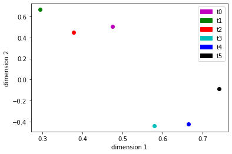

```python
import matplotlib.pyplot as plt
import matplotlib.patches as mpatches
from sklearn.decomposition import TruncatedSVD

svd = TruncatedSVD(n_components=2);
P = svd.fit_transform(Tfidf_encoding)

#grafico
color = ['m', 'g', 'r', 'c', 'b','k']
plt.figure()
patches = []

for i,texto in enumerate(textos):
    plt.plot(P[i,0], P[i,1], color[i]+"o")
    patches.append(mpatches.Patch(color=color[i], label='t'+str(i)))

plt.legend(handles=patches)
plt.xlabel('dimension 1')
plt.ylabel('dimension 2')
#plt.axis([-4, 4, -4, 4])
plt.show()
```

Las dimensiones que generamos son combinaciones lineales de los términos.

Podemos ver cuánto pesa cada término en la definición de estas dimensiones.

Ordenemos los términos en función de cuánto pesan en cada dimensión:

```python
# coeficientes (pesos) de los términos en cada una de las dos dimensiones
comp1,comp2 = svd.components_

# los ordenamos de menor a mayor y nos quedamos con los índices de sus posiciones en el array
indices=np.argsort(comp1);

# invertimos para que queden ordenados de mayor a menor
indices=indices[::-1]

# Evaluamos los términos en estas posiciones
print('Dimension 1:')
print(np.array(vectorizer.get_feature_names())[indices])

print('\n')

indices=np.argsort(comp2);
indices=indices[::-1]
print('Dimension 2:')
print(np.array(vectorizer.get_feature_names())[indices])
```

```
Dimension 1:
['potro' 'juan' 'martin' 'cine' 'tandil' 'encanto' 'ver' 'recibido'
 'multitud' 'angel' 'casualidad' 'llegaron' 'nacional' 'masas' 'dio'
 'volvio' 'suyos' 'ultimo' 'bano' 'millonaria' 'final' 'cinta' 'unica'
 'mes' 'oscar' 'paso' 'tanque' 'cerca']


Dimension 2:
['angel' 'cine' 'nacional' 'cerca' 'tanque' 'paso' 'oscar' 'casualidad'
 'llegaron' 'millonaria' 'cinta' 'final' 'mes' 'unica' 'potro' 'ver'
 'encanto' 'masas' 'dio' 'suyos' 'ultimo' 'volvio' 'bano' 'multitud'
 'recibido' 'martin' 'juan' 'tandil']
```

En la representación 2D de los textos vemos que hay dos grupos separados: uno que habla escencialmente de cine y otro que habla de tenis.

En un escenario de aprendizaje no supervisado, podríamos encontrar estos grupos mediante un algoritmo de clustering.

Conclusiones

[figure not shown]

## Conclusiones

En esta clase presentamos

- Conceptos y técnicas útiles de preprocesamiento de texto para construir features que permitan modelar problemas de aprendizaje supervisado y no supervisado.
- [NLTK (Natural Language Toolkit)](https://www.nltk.org), una librería de python de código abierto para el procesamiento de lenguaje natural.
- Reducción de dimensionalidad mediante Singular Value Decomposition

Hands-on

[figure not shown]

## Hands-on

Usando las letras de canciones en español disponibles [aquí](https://www.kaggle.com/smunoz3801/9325-letras-de-rap-en-espaol), construir una nube de palabras para identificar cuáles son las más frecuentes.

Para eso vamos a usar la bilbioteca `WordCloud` que pueden instalarla descomentando esta linea:

```python
#! conda install -c conda-forge wordcloud=1.8.1 --yes --name dhdsblend2021
```

Construimos la nube de palabras con

`wordcloud = WordCloud(width=1500, height=1500, margin=0, stopwords = mis_stop_word).generate(mi_texto)`

Y la graficamos con el método:

```python
def plot_cloud(wordcloud):
    # Set figure size
    plt.figure(figsize=(30, 20))
    # Display image
    plt.imshow(wordcloud)
    # No axis details
    plt.axis("off");
```

### Ejercicio 1

Leer en un dataframe los datos del archivo `hhgroups_merge_28_05.zip`.

Fuente: https://www.kaggle.com/smunoz3801/9325-letras-de-rap-en-espaol

Consideraremos

- documento al valor del campo `letra` de cada uno de los registros que componen el dataframe
- corpus al conjunto de documentos, es decir el conjunto de valores del campo `letra`

### Ejercicio 2

Tokenizar el corpus, hacer stemming, eliminar stopwords

Considerar "estribillo" una stopword (aparece en muchos registros y va a ser muy relevante en la nube de palabras).

### Ejercicio 3

Construir una nube de palabras para visualizar las palabras más frecuentes en las letras de estas canciones.

## Solución

### Ejercicio 1

```python
data = pd.read_csv("../Data/hhgroups_merge_28_05.zip", sep=",")
data
```

|  | id | artista | cancion | album | letra | anyo | visitas |
| --- | --- | --- | --- | --- | --- | --- | --- |
| 0 | 0 | Denom | Machete (con Jarfaiter y Gente jodida) | Medicina | Para su nuevo disco "Medicina", Denom ha vuelt... | 2019 | 126 |
| 1 | 1 | Denom | Vacío (con Ivo Incuerdo) | Medicina | [Denom]\nYo que quería, yo que pedía vida,\nSe... | 2019 | 361 |
| 2 | 2 | Denom | El orgullo es fiel (con Juancho Marqués y Elio... | Medicina | "El orgullo es fiel" es uno de los cortes incl... | 2019 | 262 |
| 3 | 3 | Denom | Mueve mueve (con Fernandocosta) | Medicina | [Estribillo: Denom] (x2)\nMueve, mueve, mueve,... | 2019 | 578 |
| 4 | 4 | Jaro Desperdizio | Insomnia | Sin álbum, es un vídeo suelto | [Estribillo]\nY en esta noche, ¿Quién me arrop... | 2019 | 219 |
| ... | ... | ... | ... | ... | ... | ... | ... |
| 9320 | 50 | Pol y Polanko | Mas o menos | Suena | Cuestiones de fianzas, tras de más desconfianz... | 2009 | 1056 |
| 9321 | 51 | Porta | Palabras mudas (con Gema) | Reset | Quiero decirte tantas cosas que no pude,\nasum... | 2012 | 20184 |
| 9322 | 52 | Porta | Causa y efecto (con H0lynaight) | Reset | [Porta]\nTenemos que hablar, esto tiene que ca... | 2012 | 16159 |
| 9323 | 53 | Doble r ce | Que sepas que te amo | Sin álbum, es un tema suelto | [Estribillo]\n(En inglés)\n\n\nNunca llegarás ... | 2012 | 4015 |
| 9324 | 54 | Arbel López | Im ready | Luces y sombras | Soy yo, hello, soy el Arbel López,\nnegrata es... | 2011 | 878 |

9325 rows × 7 columns

### Ejercicio 2

```python
corpus = data.letra
corpus
```

```
0       Para su nuevo disco "Medicina", Denom ha vuelt...
1       [Denom]\nYo que quería, yo que pedía vida,\nSe...
2       "El orgullo es fiel" es uno de los cortes incl...
3       [Estribillo: Denom] (x2)\nMueve, mueve, mueve,...
4       [Estribillo]\nY en esta noche, ¿Quién me arrop...
                              ...
9320    Cuestiones de fianzas, tras de más desconfianz...
9321    Quiero decirte tantas cosas que no pude,\nasum...
9322    [Porta]\nTenemos que hablar, esto tiene que ca...
9323    [Estribillo]\n(En inglés)\n\n\nNunca llegarás ...
9324    Soy yo, hello, soy el Arbel López,\nnegrata es...
Name: letra, Length: 9325, dtype: object
```

Tokenizar:

```python
from nltk.tokenize import word_tokenize

tokens = [word_tokenize(doc) for doc in corpus]

flat_tokens = [item for sublist in tokens for item in sublist]

flat_tokens[0:5]

#tokens_joined = ' '.join(tokens)
#tokens_joined
```

```
['Para', 'su', 'nuevo', 'disco', '``']
```

Stemming:

```python
from nltk.stem import SnowballStemmer

spanish_stemmer = SnowballStemmer('spanish', ignore_stopwords = False)

stem_tokens = [spanish_stemmer.stem(x) for x in flat_tokens]

print("cantidad de stem_tokens: ", len(stem_tokens))
```

```
cantidad de stem_tokens:  5177781
```

Stopwords:

```python
stopwords_en = stopwords.words('spanish');

stopwords_en.append("estribillo")

stopwords_es_stem = [spanish_stemmer.stem(x) for x in stopwords_en]
```

```python
stem_tokens_non_stopwords = [x for x in stem_tokens if x not in stopwords_es_stem]

print("cantidad de stem_tokens sin stopwords: ", len(stem_tokens_non_stopwords))
```

```
cantidad de stem_tokens sin stopwords:  2957531
```

### Ejercicio 3

```python
from wordcloud import WordCloud

# no pasamos la lista de stopwords porque ya las quitamos en el ejercicio anterior:

mi_texto = ' '.join(stem_tokens_non_stopwords)

mywordcloud = WordCloud(width=1500, height=1500, margin=0, stopwords = None).generate(mi_texto)
```

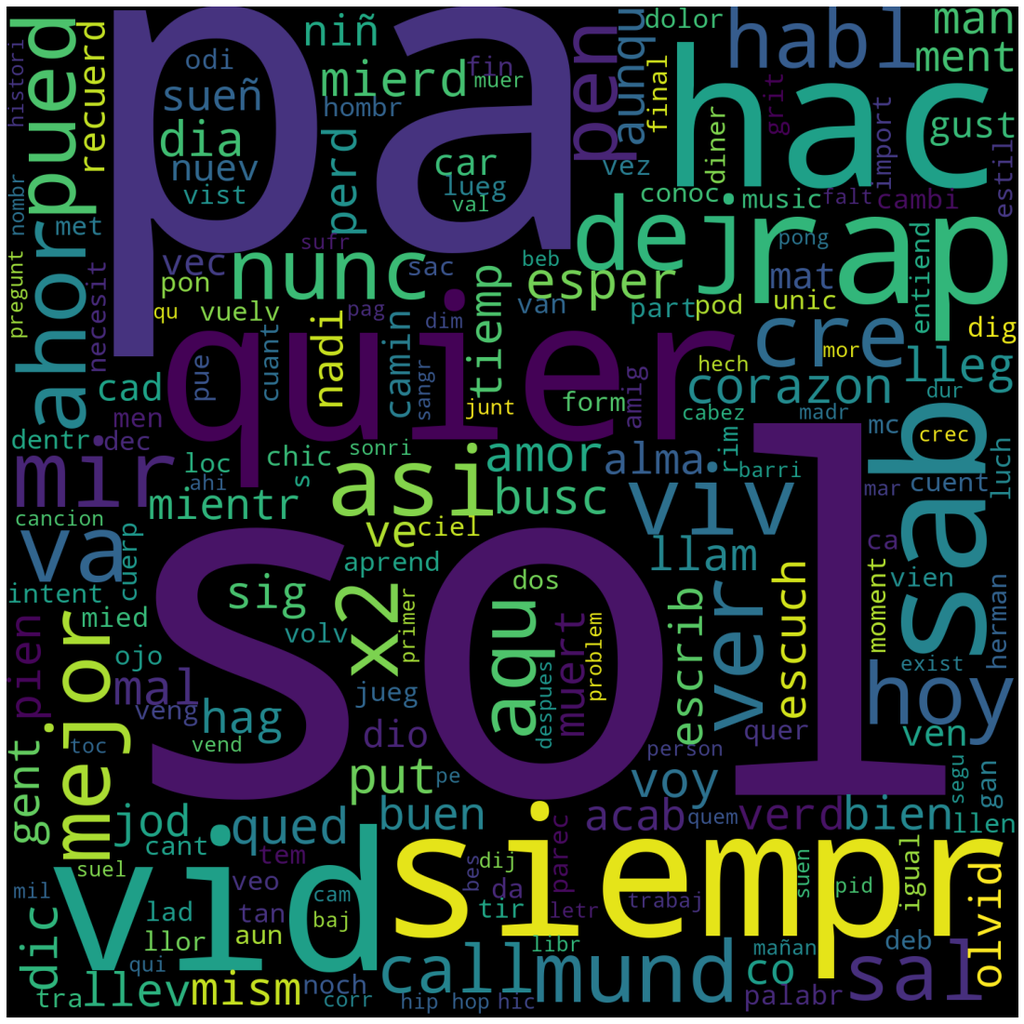

```python
plot_cloud(mywordcloud)
```

Referencias y material adicional

[figure not shown]

## Referencias

[Natural Language Processing with Python.](http://nltk.org/book) Steven Bird, Ewan Klein, and Edward Loper (2009). O’Reilly Media Inc.

[How tokenizing text, sentence, words works](https://www.geeksforgeeks.org/nlp-how-tokenizing-text-sentence-words-works/)

[TF(Term Frequency)-IDF(Inverse Document Frequency) from scratch in python](https://towardsdatascience.com/tf-term-frequency-idf-inverse-document-frequency-from-scratch-in-python-6c2b61b78558)